# Pseudobulk sgRNA GEX effects CTR02

Eric Wang

2024-07-13

## Data Import

```r
data <- readRDS("processing/CTR02_seurat_SCT_CRISPRumi9.rds")
```

Add some metadata columns

```r
data <- subset(data, subset = num_features == 1)
data$feature_gene <- gsub("\\..*","",data$feature_call)
# split hash ID into separate organ and CD62L status
hashSplit <- data@meta.data %>%
  dplyr::select(hash.ID) %>%
  separate(hash.ID,c("organ","CD62L_status"), sep = "-")
data$organ <- hashSplit$organ
data$CD62L_status <- hashSplit$CD62L_status
```

## Examine sgRNA distributions

```r
p1 <- data@meta.data %>%
  group_by(feature_call) %>%
  summarise(count = n()) %>%
  ggplot(aes(x = feature_call, y = count)) +
    geom_bar(stat = "identity") +
    theme(axis.text.x = element_text(angle = 45, hjust = 1))

p2 <- data@meta.data %>%
  group_by(organ,feature_gene) %>%
  summarise(count = n()) %>%
  ggplot(aes(x = feature_gene, y = count, fill = feature_gene)) +
    geom_bar(stat = "identity") +
    facet_wrap(~organ) +
    scale_fill_brewer(palette = "Dark2")
p3 <- data@meta.data %>%
  group_by(CD62L_status,feature_gene) %>%
  summarise(count = n()) %>%
  ggplot(aes(x = feature_gene, y = count, fill = feature_gene)) +
    geom_bar(stat = "identity") +
    facet_wrap(~CD62L_status) +
    scale_fill_brewer(palette = "Dark2")
```

[output not shown]

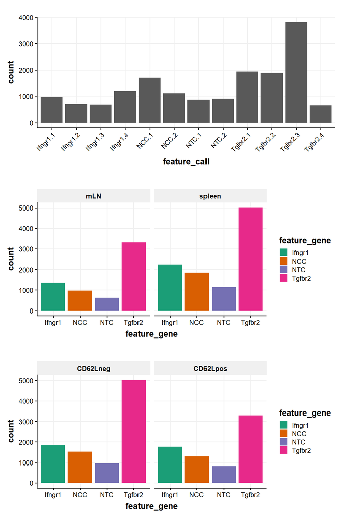

```r
grid.arrange(p1,p2,p3)
```

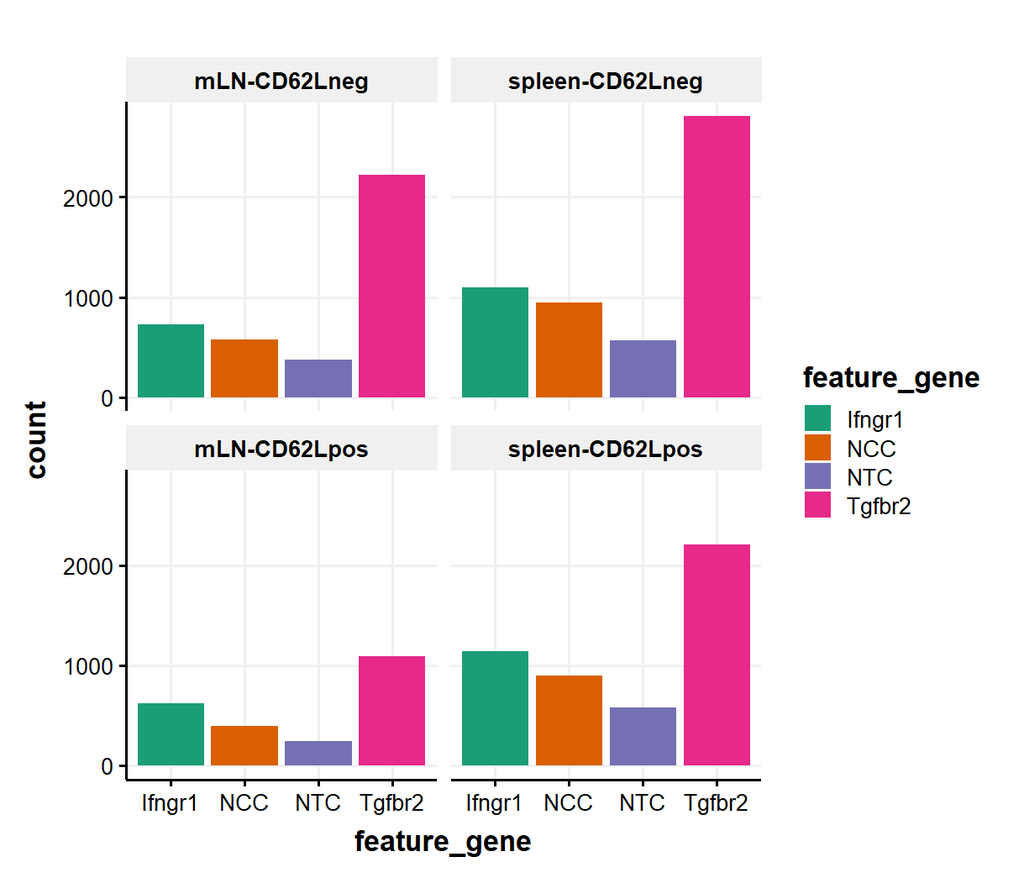

```r
data@meta.data %>%
  group_by(hash.ID,feature_gene) %>%
  summarise(count = n()) %>%
  ggplot(aes(x = feature_gene, y = count, fill = feature_gene)) +
    geom_bar(stat = "identity") +
    facet_wrap(~hash.ID) +
    scale_fill_brewer(palette = "Dark2")
```

## Psuedobulk by sgRNA

```r
p1 <- DESeq2::plotPCA(ddsNorm, intgroup = "feature_gene", ntop=2000) + theme(aspect.ratio = 1) +
  scale_color_brewer(palette = "Dark2") +
  ggtitle("Pseudobulk by Gene Target")
```

```
using ntop=2000 top features by variance
```

```r
p2 <- DESeq2::plotPCA(ddsNorm, intgroup = "mito_perc", ntop=2000) +
  theme(aspect.ratio = 1) +
  scale_color_viridis() +
  ggtitle("Pseudobulk by Mito Percentage")
```

```
using ntop=2000 top features by variance
```

```r
p3 <- DESeq2::plotPCA(ddsNorm, intgroup = "median_sgRNA_umi", ntop=2000) +
  theme(aspect.ratio = 1) +
  scale_color_viridis() +
  ggtitle("Pseudobulk by Median sgRNA UMI")
```

```
using ntop=2000 top features by variance
```

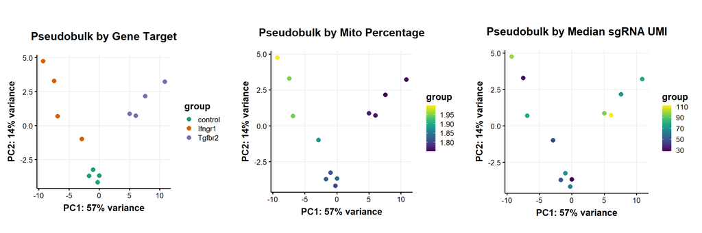

```r
grid.arrange(p1,p2,p3, ncol=3)
```

*It’s interesting that Ifngr1 KO cells have higher mitochondrial percentage. Also interesting that Tgfbr2 KO have higher median sgRNA UMI (perhaps because they are more proliferative?).* These could be features of the scRNA-seq dataset that are biologically relevant and “orthogonal” to DEG analysis alone.

### Correlation Matrices

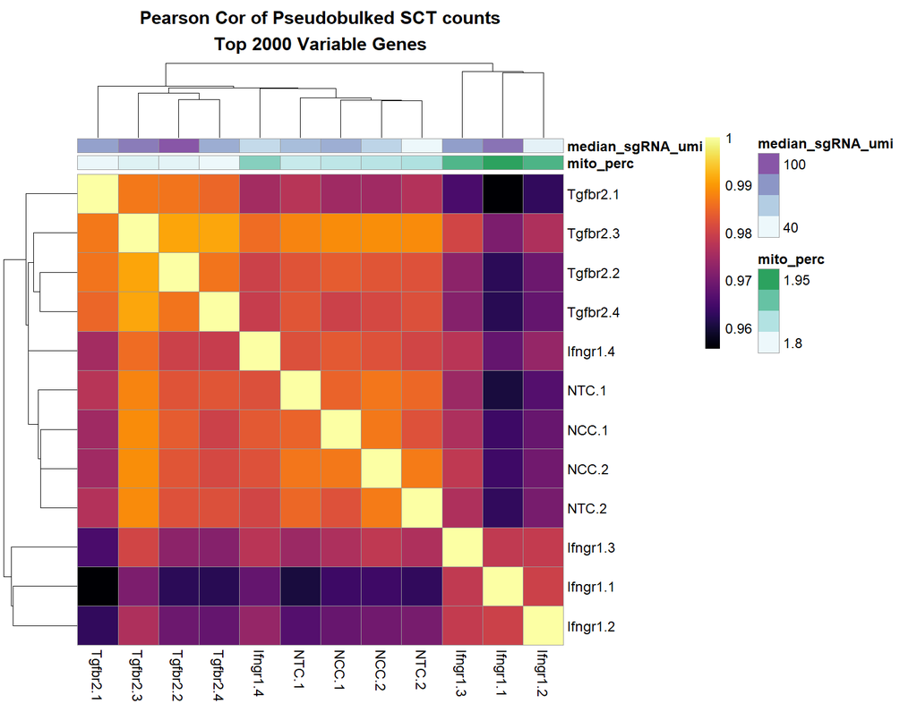

```r
# Extract the normalized matrix from the object and compute pairwise correlation values
dds_mat <- assay(ddsNorm)[varGenes,]
dds_cor <- cor(dds_mat)

# Plot heatmap
pheatmap(dds_cor, annotation = ddsColData[, c("mito_perc","median_sgRNA_umi"), drop=F],
         color = viridis(n = 256, alpha = 1, option = "inferno"), clustering_method = "single",
         main = "Pearson Cor of Pseudobulked SCT counts\nTop 2000 Variable Genes")
```

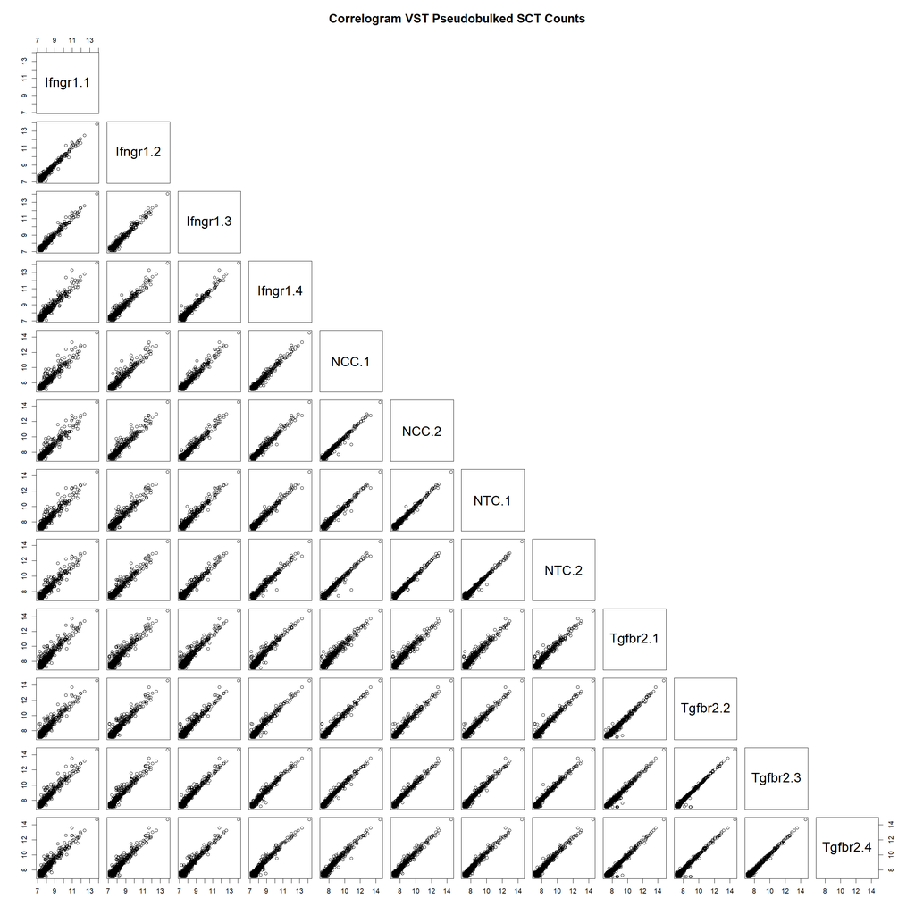

```r
pairs(dds_mat, upper.panel = NULL, main = "Correlogram VST Pseudobulked SCT Counts")
```

Here I will look at the correlation between guides that are pseudobulked and then Zscored in comparison to the control guides (NCC and NTC)

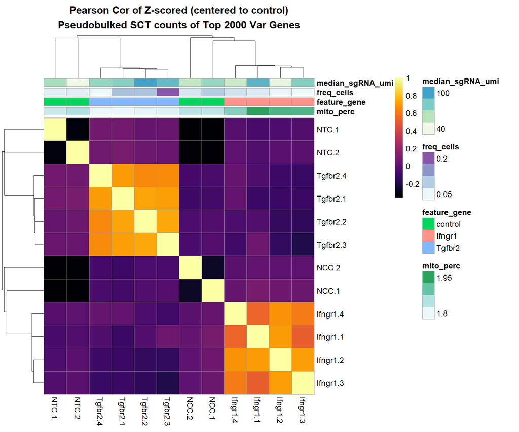

```r
# Extract the normalized matrix from the object and compute pairwise correlation values
dds_mat <- assay(ddsNorm)
dds_mat <- dds_mat[varGenes,]

controlMat <- dds_mat[,grepl("NCC|NTC",colnames(dds_mat))]
controlMean <- apply(controlMat, 1, mean) %>% as.matrix()
controlSD <- apply(controlMat, 1, sd) %>% as.matrix()

# calculate Zscore for each gene using mean and SD from control groups
ddsZscore <- data.frame(row.names = rownames(dds_mat))
for(i in 1:ncol(dds_mat)){
  ddsZscore[,i] <- (dds_mat[,i]-controlMean)/controlSD
}
colnames(ddsZscore) <- colnames(dds_mat)
# remove NA and Inf
ddsZscore <- ddsZscore[is.finite(rowSums(ddsZscore)),]

# construct correlation matrix
dds_cor <- cor(ddsZscore, use = "complete.obs") %>%
  as.matrix()

# Plot heatmap
pheatmap(dds_cor, annotation = ddsColData[, c("mito_perc","feature_gene","freq_cells","median_sgRNA_umi"), drop=F],
          color = viridis(n = 256, alpha = 1, option = "inferno"), clustering_method = "single",
         main = "Pearson Cor of Z-scored (centered to control)\nPseudobulked SCT counts of Top 2000 Var Genes")
```

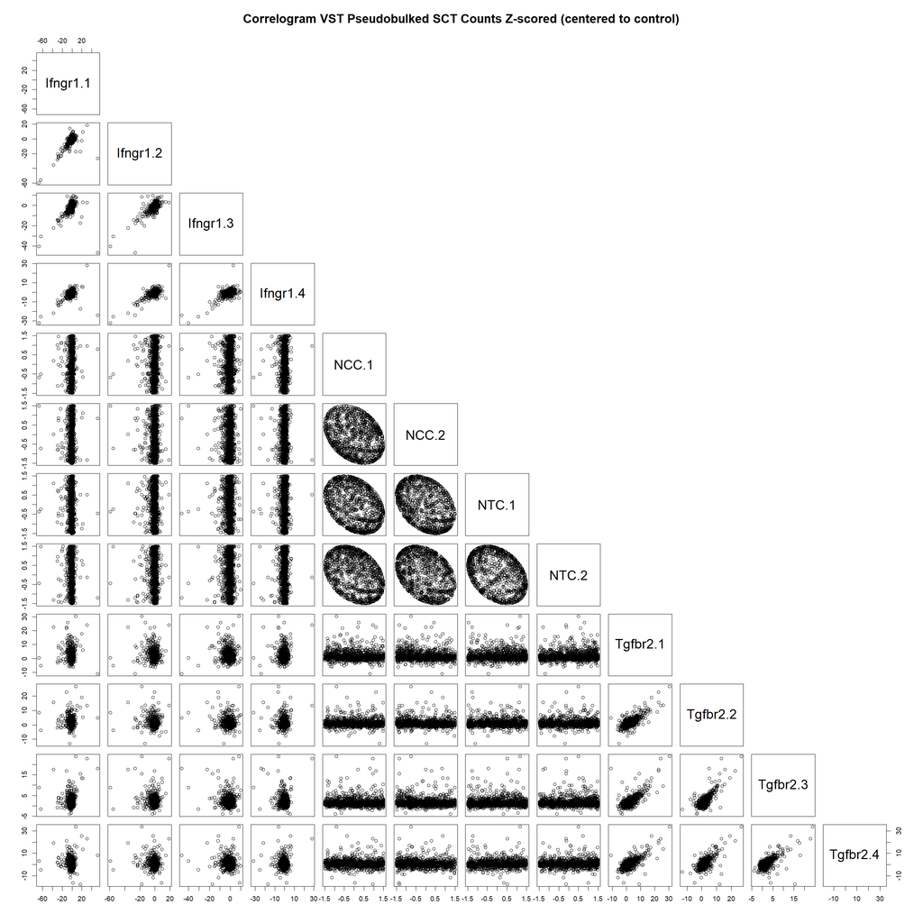

```r
pairs(ddsZscore, upper.panel = NULL,
      main = "Correlogram VST Pseudobulked SCT Counts Z-scored (centered to control)")
```